# Birthweight - Robust Regression

## Case Study 1: Birthweight

Birthweight is a commonly-used indicator of a newborn infant’s health status. Because this indicator is easily obtained, it is a critical component of population health reporting by the World Health Organization and governments around the globe. The distribution of birthweight has often been described as approximately normal, though the left tail in particular is inflated relative to that from a Gaussian distribution.

## Dealing with heavy-tailed distributions

Birthweight has heavy tails, or more observations in the tail than a typical normal distribution.

Fitting an OLS model assumes the data follows a normal distribution. Instead we may want to consider a parametric family that has heavier tails and therefore better fits to the outliers in the data.

Let’s first start by fitting the model with a linear regression.

## Read data into R

We will use the birth data here, and measure whether there is a relationship between the response, birthweight, and the explanatory variables, gestational age and sex.

- Check for NAs in data - appear as 99, 9999
- For now, remove the rows with missing values
- Only look at most recent year, 2016

```r
#Read in birth data
o_data <- read.csv("~/Documents/case-studies/data/2011-2016 Vital Files Duke_Herring/Yr1116Birth.csv", na.strings=c(99,9999))
o_data$SEX = ifelse(o_data$SEX==9, NA, o_data$SEX)

#Remove NAs and restrict to year 2016 - for demonstrations purposes
birth_data <- na.omit(o_data)
birth_data_2016 <- birth_data[which(birth_data$YOB==2016),]
```

## Is birthweight normally distributed?

- Compare histogram of birthweight to a normal distribution parameterized with a mean and variance that is set based on birthweight variable, `BWTG`.
- Do the distributions align?

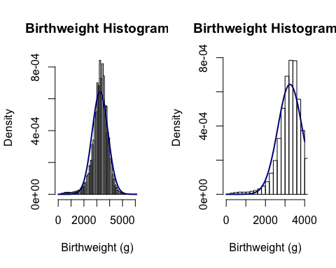

## Review of linear regression

Let $y_i$ denote the observed response, ‘BWTG’, for observation $i$, and $x_i$ the observed covariates, ‘GEST’ and ‘SEX’. Then we aim to learn the model:

$$y_i = \beta_0 + \beta_1 \text{GEST}_i + \beta_2 \text{SEX}_i + \epsilon_i$$

When we fit the line, we estimate the coefficients $\mathbf{\hat{\beta}}= \{\hat{\beta_0}, \hat{\beta_1}, \hat{\beta_2}\}$, where $\hat{\beta} = (X^\prime X)^{-1} X^\prime Y$.

$$y_i = \hat{\beta_0} + \hat{\beta_1} \text{GEST}_i + \hat{\beta_2} \text{SEX}_i + \epsilon_i$$
We denote residuals, $e_i = y_i - \hat{y_i}$ where $\hat{y_i}$ is the estimated predicted value for observation $i$.

## Model Assumptions

To make inference on the model parameters, $\beta$, we check four assumptions for the linear regression model:

1. The mean of the response, $E(Y_i) = \beta_0 + \beta_1 \text{GEST}_i + \beta_2 \text{SEX}_i$ is **linear function** of the $x_i$ at each value of the predictors $x_i$.
2. The errors, $\epsilon_i$, are **independent**.
3. The errors, $\epsilon_i$, at each value of the predictor, $x_i$, are **normally distributed**.
4. The errors, $\epsilon_i$, at each value of the predictor, $x_i$, have **equal variances**.

Or in summary, we assume the errors, $\epsilon_i$, are independent, normally distributed with zero mean and constant variance:
$$\epsilon_i \sim \text{Normal}(0, \sigma^2)$$

## Fit regression to data

Let’s fit a linear model using OLS with function `lm`.

```r
model1 = lm(BWTG~GEST+as.factor(SEX), data=birth_data_2016)
summary(model1)
```

```
##
## Call:
## lm(formula = BWTG ~ GEST + as.factor(SEX), data = birth_data_2016)
##
## Residuals:
##     Min      1Q  Median      3Q     Max
## -3034.4  -294.4   -21.9   271.2  4849.1
##
## Coefficients:
##                   Estimate Std. Error t value Pr(>|t|)
## (Intercept)     -3924.2955    21.5866 -181.79   <2e-16 ***
## GEST              188.1087     0.5594  336.27   <2e-16 ***
## as.factor(SEX)2  -127.5121     2.5574  -49.86   <2e-16 ***
## ---
## Signif. codes:  0 '***' 0.001 '**' 0.01 '*' 0.05 '.' 0.1 ' ' 1
##
## Residual standard error: 442.5 on 119852 degrees of freedom
## Multiple R-squared:  0.4902, Adjusted R-squared:  0.4902
## F-statistic: 5.762e+04 on 2 and 119852 DF,  p-value: < 2.2e-16
```

## Model diagnostics: Residual vs. Fitted

First we compare the residuals versus fitted values. This plot shows a few violations of the assumptions:

1. The mean, $E[Y_i]$ does not follows a linear relationship. The plot shows evidence of a possible quadratic relationship - residuals make a curved shape.
2. The variance changes for different fitted values, creates a cone-like shape signifying increasing variance.
3. There are multiple outliers detected in the plot with residuals greater than 2000!

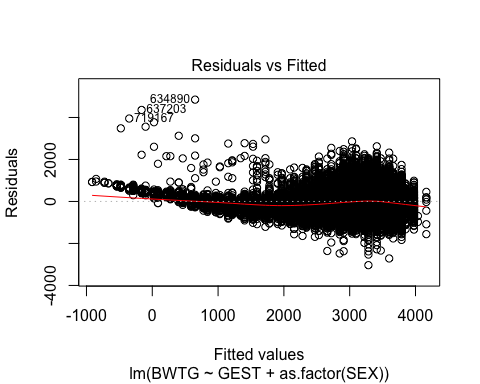

```r
plot(model1, which=1)
```

## Model diagnostics: Residual vs. Order

Next we look at the residuals versus order, which gives us a view into the independence assumption. Here the assumption holds. For violations of this assumption, look for a linear trend or some systematic pattern that would suggest non independence.

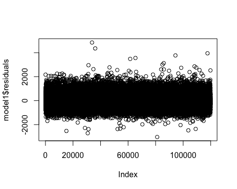

```r
plot(model1$residuals)
```

## More residual plots

We use a qqplot to determine if the residuals are normally-distributed.

- The large tail on the upper right of the plot shows that the tails of our data are heavier than that of a normal distribution - confirming what we saw in EDA.

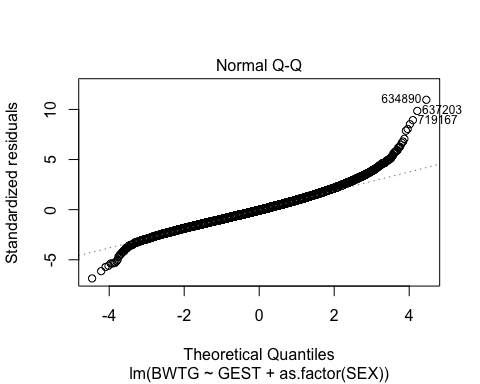

```r
plot(model1, which=2)
```

## Diagnosing the problem

Diagnostic plots of the model are essential for checking model fit. We see that a linear model may not be appropriate for our data. What are our options?

A few tools for heavy-tailed data:

- **Transformations** (e.g. sqrt(BTWG)) - transforming outcome may fix the skewness, but can make interpretting the model more difficult
- **Bayesian robust regression** - change parametric assumption (e.g. t-distribution)
- **Frequentist robust regression** - weigh observations differently based on how well behaved these observations are (a form of weighted and reweighted regression)

## Bayesian Robust Regression

Under the Bayesian approach to robust regression, we change the parametric assumptions of the errors.

- For a OLS estimate, the conditional distribution of individual response, $y_i$, given $X_i$:

$$p(y_i|X_i\beta, \sigma^2) = N(y_i|X_i\beta, \sigma^2)$$

- For robust regression, the errors follow a student-t distribution, where conditional distribution looks like:

$$p(y_i|X_i\beta, \sigma^2) = t_\nu(y_i|X_i\beta, \sigma^2)$$

- Student-t has heavier tails compared to the normal distribution.
- Degrees of freedom, $\nu$, controls the heaviness of the tails, where the larger the degrees of freedom, the closer to normal the distribution becomes
- Fitting this model is not very different from a linear regression, due to the scale mixture relationship between student-t and normal

## Bayesian robust regression in R

Consider the Bayesian approach for robust regression using package `brms`. We specify the family as `student()` to tell ‘brm’ to use a different distribution for the errors.

- `brms` fits this model using Hamiltonian Monte-Carlo through `stan`

```r
install.packages("brms", dependencies=TRUE)
require(brms)
#Specify family as student().
#We also set chains=2 for faster computation and tell the computer to split work over 2 cores.
fit1 <- brm(formula = BWTG ~ GEST+as.factor(SEX) ,
            data = birth_data_2016, family = student(), cores = 2, chains=2)
```

## Checking model fit with `brms`

How do the coefficient estimates compare?

```r
summary(fit1)
```

[output not shown]

Rhat in the table measures convergence of the chains, where 1 means convergence occurred.

## Checking model fit with `brms`

We can also check convergence through looking at trace plots:

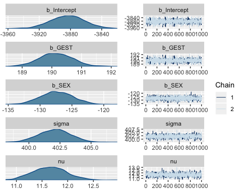

```r
plot(fit1)
```

- Chains intersect (may want to try more than 2) and appear stationary

## Alternative robust regression in R

We explore a Frequentist version of robust regression with `rlm` in `MASS` package.

- This is a form of reweighted least squares - specifically the M-estimation with Huber weighting.
- The model estimation becomes:

$$\sum_{i=1}^n w_i(y_i–x_i^\prime \beta)x_i^\prime=0$$
where $w_i$ are the weights that depend on residuals.

$$w_i =
\begin{cases}
1 & |e_i| <= k\\
\frac{k}{|e_i|} & |e_i| > k
\end{cases}$$

- We therefore solve this model with Iteratively Reweighted Least Squares (IRLS), where the coefficients at each iteration $j$ are:

$B_j=[X^\prime W_{j−1}X]^{-1} X^\prime W_{j-1} Y$

## Robust regression in R

We fit the same regression using the `rlm` function. How do the estimated coefficients compare to the linear model?

```r
library(MASS)
fit2 <- rlm(BWTG ~ GEST+as.factor(SEX), data = birth_data_2016)
summary(fit2)
```

```
##
## Call: rlm(formula = BWTG ~ GEST + as.factor(SEX), data = birth_data_2016)
## Residuals:
##       Min        1Q    Median        3Q       Max
## -3023.276  -283.100    -9.407   283.900  4890.780
##
## Coefficients:
##                 Value      Std. Error t value
## (Intercept)     -4020.1986    21.2655  -189.0475
## GEST              190.2897     0.5511   345.2991
## as.factor(SEX)2  -127.8241     2.5194   -50.7365
##
## Residual standard error: 419.8 on 119852 degrees of freedom
```

## Visualizing model fits

Does `rlm` seem to improve the model fit?

- `rlm` adjusts for outliers, but will not fix the non-constant variance

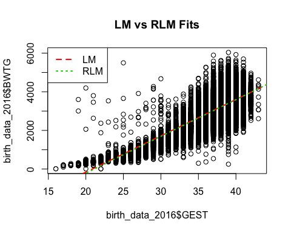

```r
#Plot data with regression fits on top -
#using only first two coefficients that correspond to intercept and gestational age (ignoring SEX)
par(mfrow=c(1,1))
plot(y=birth_data_2016$BWTG, x=birth_data_2016$GEST, main="LM vs RLM Fits")
abline(model1, lty=2, col=2, lwd=2)
abline(fit2, lty=3, col=3, lwd=2)
legend("topleft", c("LM", "RLM"), lty=c(2,3), col=c(2,3), lwd=2)
```

## Understanding resulting weights

`rlm` works by reweighting the observations with large residuals. Let’s look at the observations with the largest and smallest weights. What do you notice about the data and the residuals?

```r
fit2_weights = data.frame(bwt = birth_data_2016$BWTG, gest = birth_data_2016$GEST, resid=fit2$resid, weight=fit2$w)
fit2_weights[order(fit2$w)[c(1:5, (length(fit2$w)-5):length(fit2$w))],]
```

```
##         bwt gest     resid    weight
## 634890 5500   25 4890.7799 0.1154439
## 637203 4196   20 4410.4044 0.1280191
## 719167 3600   19 4004.6941 0.1409891
## 695779 3799   21 3823.1147 0.1476853
## 666581 3459   21 3610.9388 0.1563631
## 721683 3055   37  162.3034 1.0000000
## 721684 3000   39 -273.2760 1.0000000
## 721686 3510   39  236.7240 1.0000000
## 721688 3487   39  213.7240 1.0000000
## 721689 3715   39  313.8999 1.0000000
## 721690 3402   37  509.3034 1.0000000
```

## Class Exercises:

- Evaluate the observations with largest residuals/weights and discuss possible reasons for the large residual.
- Continue model-fitting with `rlm` exploring the remaining covariates
- Create a test set of observations and measure how well we can predict those values
  - Use mean squared error to measure prediction accuracy
- What are the top predictors of birthweight?
- With extra time, try the `brms` package fitting the data using the student-t distribution